# Text Mining Saudi Aramco Prospectus

Rafael Nicolas Fermin Cota (nico)

2021-08-12

# Extracting the prospectus text with pdftools

We used the [pdftools] package by [ROpenSci] to extract the text from the document, using the prospectus posted by Saudi Aramco, [available here](https://www.saudiaramco.com/-/media/images/investors/saudi-aramco-prospectus-en.pdf). Extracting the text was as simple as downloading the PDF and running `pdftools::pdf_text()`. We added page and line numbers to the extracted text and stored the result as a CSV.

```r
library(knitr)
library(ggpage)
library(pdftools)
library(magrittr)
library(tidyverse)
```

```r
path_root=file.path("..", "..")
# Download report from link above
aramco_prospectus_pdf <- pdf_text(
  file.path(path_root, "data", "saudi-aramco-prospectus-en.pdf")
)

aramco_prospectus_text <- tibble( # https://www.tidytextmining.com
  page = 1:length(aramco_prospectus_pdf),
  text = aramco_prospectus_pdf
) %>%
  separate_rows(text, sep = "\n") %>%
  group_by(page) %>%
  mutate(line = row_number()) %>%
  ungroup() %>%
  select(page, line, text)

# write_csv(aramco_prospectus_text, file.path("data", "saudi-aramco-prospectus-en.csv"))
# head(aramco_prospectus_text) %>% kable
```

## Visualizing the prospectus pages with ggpage

Emil Hvitfeldt released [ggpage], a package that lets you create a page-layout visualization using [ggplot2]. While the package uses the text content of the document only — so the visualized text layout doesn’t completely match the layout of the original document — it does allow you to highlight text elements.

The core of the next step is to pass the `aramco_prospectus_pages` to `ggpage::ggpage_build()`. Before doing that, though, we pad each page to make sure they have the same number of lines.

The `ggpage_build()` function tokenizes the text into individual `word`s, so we then use `str_detect()` to find mentions of the key players.

```r
aramco_prospectus_pages <- aramco_prospectus_text %>%
  # pad pages with fewer lines than expected
  complete(
    page,
    line = 1:max(aramco_prospectus_text$line),
    fill = list(text = "")
  ) %>%
  # Pre-process for {ggpage}
  ggpage_build(
    ncol = 30,
    bycol = FALSE,
    page.col = "page",
    wtl = FALSE,
    x_space_pages = 10,
    y_space_pages = 100
  ) %>%
  mutate(
    color = case_when(
      str_detect(word, "reserves|life") ~ "Reserves",
      str_detect(word, "gearing")     ~ "Gearing",
      str_detect(word, "roace")      ~ "Capital",
      TRUE ~ "risk"
    ),
    color = factor(color, c(
      "Reserves", "Gearing", "Capital", "risk"
    ))
  )
# aramco_prospectus_pages
```

The following bit of code sets up the color palette, which is derived from the `Libre Office Calc` theme provided by [ggthemes].

```r
# manually assigned colors from ggthemes::pal_calc()
colors <- rep("", length(levels(aramco_prospectus_pages$color)))
names(colors) <- levels(aramco_prospectus_pages$color)
colors["Reserves"]    <- "#FF4023"
colors["Gearing"]   <- "#004983"
colors["Capital"]    <- "#FF922E"
colors["risk"]   <- "#d0d0d0"
```

Finally, `ggpage_plot()` from ggpage creates the ggplot2 page layout, and adding the fill aesthetic using the manual color scale defined above adds color highlights for mentions of Reserves, Gearing, and others.

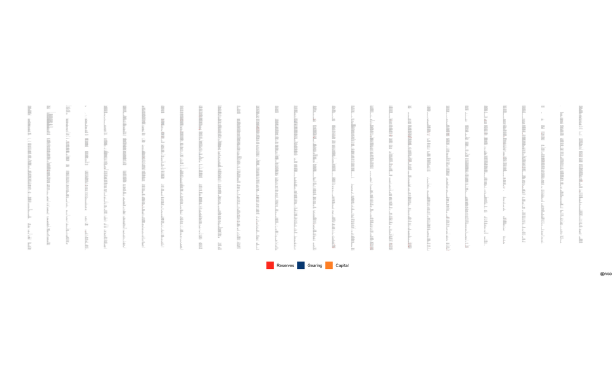

```r
# pdf(file="aramco_prospectus_pages.pdf")

ggpage_plot(aramco_prospectus_pages) +
  aes(fill = color) +
  scale_fill_manual(
    values = colors,
    breaks = setdiff(names(colors), "risk")
  ) +
  labs(fill = NULL, caption = "@nico") +
  guides(fill = guide_legend(nrow = 1)) +
  theme(legend.position = "bottom")

# dev.off()
```

*Click the image to expand.*